# Simus GWAS with relatedness

Florian Privé

June 8, 2019

## Simu design

### Data

- Use genotyped SNPs of UKBB with MAF > 1% and INFO > 0.99 (P = 656,060).
- Use individuals (British, no structure) within pairs of related individuals with Kinship > 0.1 (N = 59,532).

### Phenotype

- Simulate quantitative phenotype with h2 = 0.5 and m = 50K causal variants (amongst odd chromosomes only).

## Results

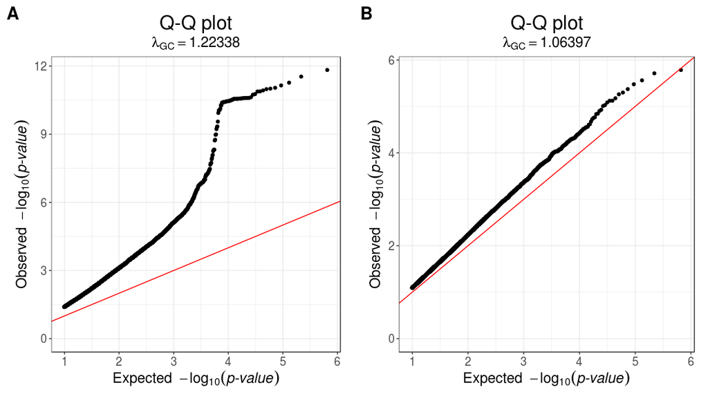

Q-Q plots for standard GWAS. A: odd chromosomes. B: even chromosomes.

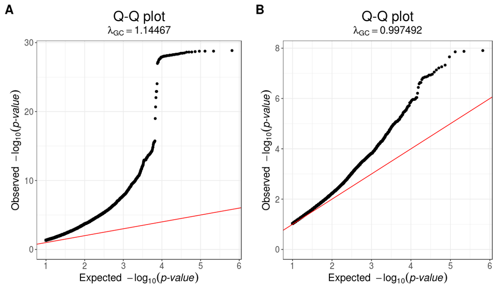

Q-Q plots for GWAS with polygenic effect. A: odd chromosomes. B: even chromosomes.

Null SNPs are inflated with standard GWAS. For GWAS with polygenic effect, even if $\lambda_{GC}$ is close to 1, the inflation for top SNPs is larger. Explanation?

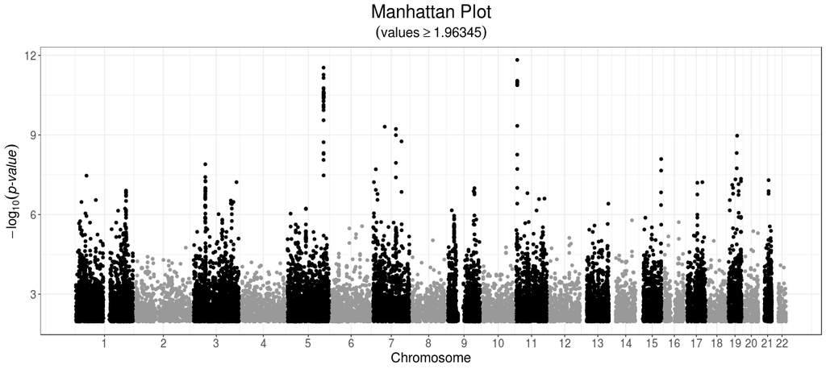

Manhattan plot for standard GWAS.

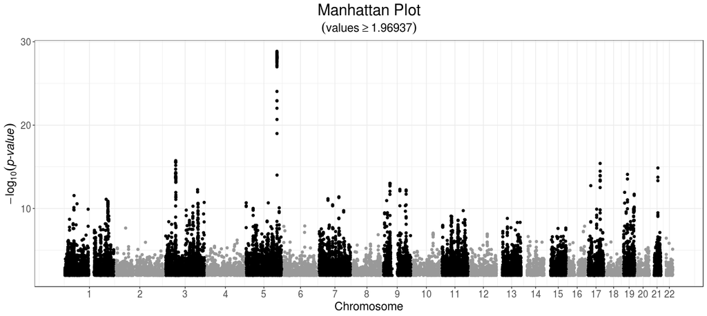

Manhattan plot for GWAS with polygenic effect.

Power increase.

### BOLT-LMM

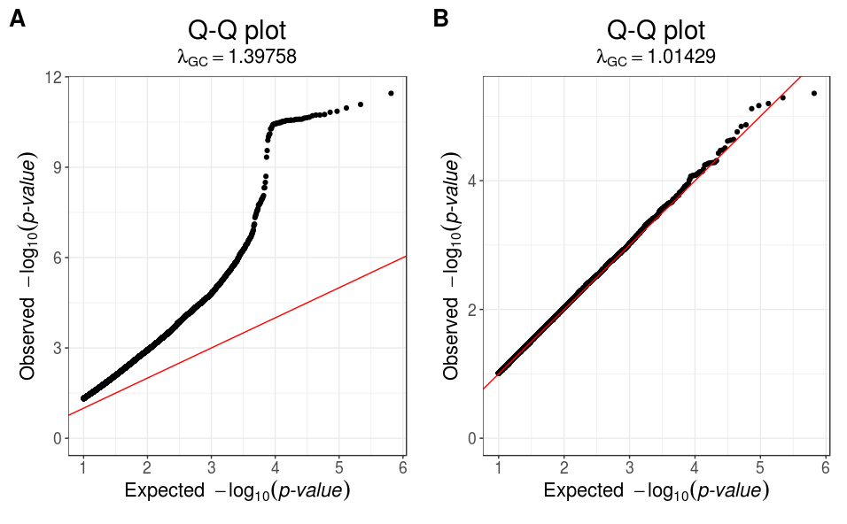

Q-Q plots for GWAS with BOLT-LMM. A: odd chromosomes. B: even chromosomes.

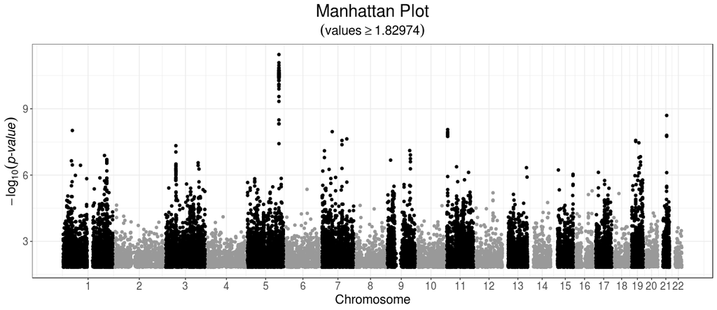

Manhattan plot for GWAS with BOLT-LMM.

**Warning**: BOLT-LMM uses $\chi^2$ statistics and standard GWAS uses $t$ statistics, but $\lambda_{GC}(\chi^2) = (\lambda_{GC}(t))^2$.

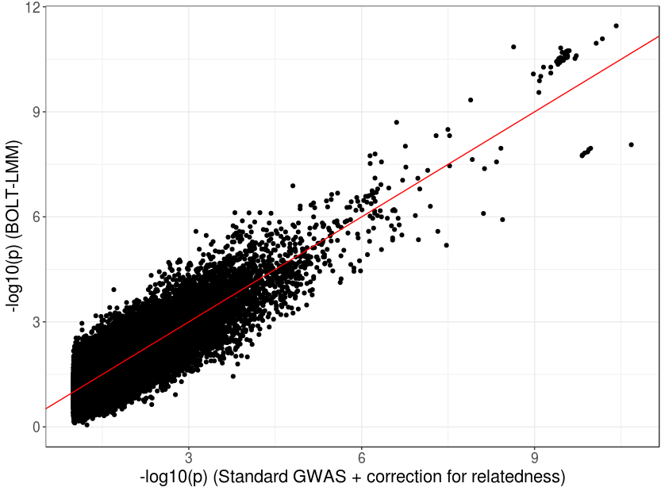

### LDSC

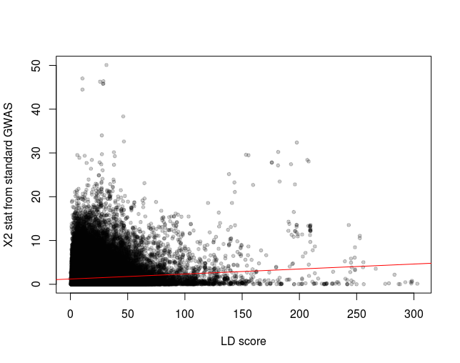

LD score regression for standard GWAS.

What am I doing wrong?

### Correct for relatedness in standard GWAS?

Random idea I had: do GWAS with one of the genotype as phenotype (excluding all SNPs from the same chromosome) to get a sense of the impact of relatedness.

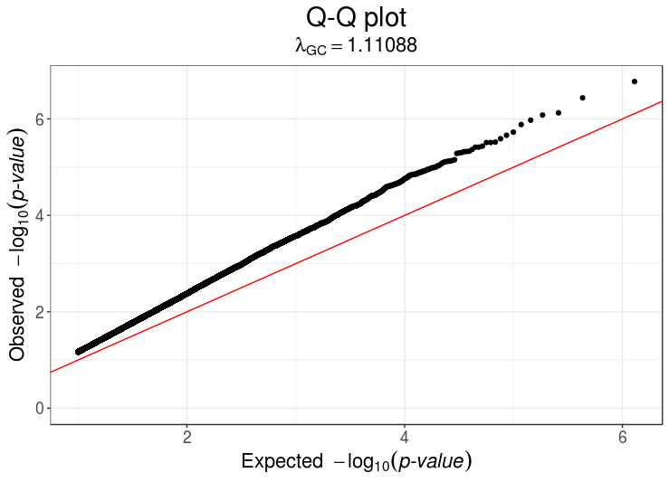

Q-Q plot for standard GWAS with one genotype as phenotype.

If we call this $\lambda_{GC}$ “$\lambda_{rel}$”, then for a phenotype with heritability h2, it seems that $\lambda_{GC}$ = $\lambda_{rel}^{h2}$.

If we apply this correction for first GWAS:

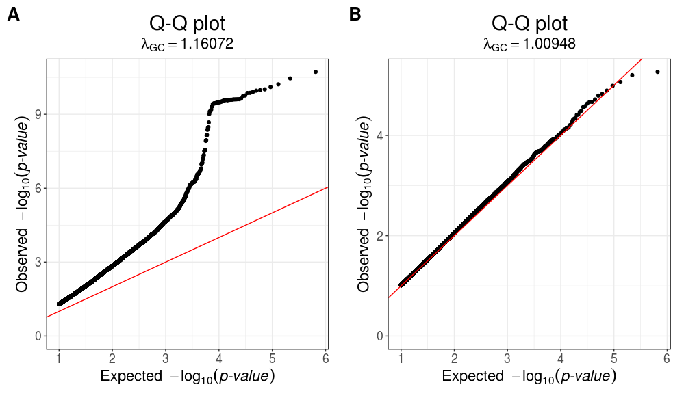

Q-Q plots for standard GWAS corrected by $\lambda_{rel}^{h2}$. A: odd chromosomes. B: even chromosomes.